# Problem Set 2

Aijing Gao

September 5, 2017

# Simulation on ICC

```r
library(ICC)
library(htmlTable)
library(ggplot2)
library(gtools)
library(data.table)
library(dplyr)
library(magrittr)
library(chron)
library(reshape2)
library(corrplot)
library(zoo)
library(plotly)
#this function returns simulated data with target ICC (target), number of groups (k),
#total sample size (n), overall mean (mu), within standard deviation (sigmaw)
get_data<-function(target, n, k, mu, sigmaw){
  #set seed for simulations
  set.seed(1112)
  #create label for group
  group <- factor(rep(1:k, each = n/k))
  #create simulated y value for simulated target
  sigmab<-sqrt(sigmaw^2*target/(1-target))
  value <- c(sapply(rnorm(k,mu,sigmab), function(mui) rnorm(n/k, mui, sigmaw))) # observations
  data <- data.frame(group = group, value = value)
  return(data)
}
```

1. Simulate data with a theoretical ICC of 0.1 and 0.9 across k = 10 groups using a total sample size of n = 100.

```r
#write function to return summarized statistics for simulations
get_est<-function(target, n, k, mu = 5, sigmaw = 0.1){
  dat<-get_data(target, n, k, mu, sigmaw)
  result<-ICCest(dat$group, dat$value)
  estimate<-paste0(round(result$ICC, digits = 2),
                 "[95% CI:",
                 round(result$LowerCI, digits = 2),
                 "-",
                 round(result$UpperCI, digits = 2),
                 "]")
  Tab<-data.frame(Theoretical = target,
                Simulated = estimate,
                `Sample Size` = n,
                Group = k,
                lowerbound = result$LowerCI,
                upperbound = result$UpperCI,
                ICC = result$ICC)
  return(Tab)
}

Tab1<-rbind(get_est(0.1, 100, 10), get_est(0.9, 100, 10))

#Summarize the results from simulation by table
htmlTable(Tab1[,-c(5:7)], caption = "Table 1. Empirical Analysis of simulations for estimating ICC (n=100; k=10)")
```

| Table 1. Empirical Analysis of simulations for estimating ICC (n=100; k=10) | Table 1. Empirical Analysis of simulations for estimating ICC (n=100; k=10) Theoretical | Table 1. Empirical Analysis of simulations for estimating ICC (n=100; k=10) Simulated | Table 1. Empirical Analysis of simulations for estimating ICC (n=100; k=10) Sample.Size | Table 1. Empirical Analysis of simulations for estimating ICC (n=100; k=10) Group |
| --- | --- | --- | --- | --- |
| 1 | 0.1 | 0.06[95% CI:-0.03-0.31] | 100 | 10 |
| 2 | 0.9 | 0.84[95% CI:0.69-0.95] | 100 | 10 |

Summarized results were shown in Table 1.

(b). Repeat using a total sample size of n = 1, 000.

```r
Tab2<-rbind(get_est(0.1, 1000, 10), get_est(0.9, 1000, 10))
#conclude the results from simulation
htmlTable(Tab2[,-c(5:7)], caption = "Table 2. Empirical Analysis of simulations for
          estimating ICC (n=1000; k=10)")
```

| Table 2. Empirical Analysis of simulations for estimating ICC (n=1000; k=10) | Table 2. Empirical Analysis of simulations for estimating ICC (n=1000; k=10) Theoretical | Table 2. Empirical Analysis of simulations for estimating ICC (n=1000; k=10) Simulated | Table 2. Empirical Analysis of simulations for estimating ICC (n=1000; k=10) Sample.Size | Table 2. Empirical Analysis of simulations for estimating ICC (n=1000; k=10) Group |
| --- | --- | --- | --- | --- |
| 1 | 0.1 | 0.06[95% CI:0.03-0.2] | 1000 | 10 |
| 2 | 0.9 | 0.86[95% CI:0.74-0.95] | 1000 | 10 |

(c)Keep the sample size at n = 1, 000 but increase the number of groups to k = 100.

```r
Tab3<-rbind(get_est(0.1, 1000, 100), get_est(0.9, 1000, 100))
#conclude the results from simulation
htmlTable(Tab3[,-c(5:7)], caption = "Table 3. Empirical Analysis of simulations
          for estimating ICC (n=1000 and k=100)")
```

| Table 3. Empirical Analysis of simulations for estimating ICC (n=1000 and k=100) | Table 3. Empirical Analysis of simulations for estimating ICC (n=1000 and k=100) Theoretical | Table 3. Empirical Analysis of simulations for estimating ICC (n=1000 and k=100) Simulated | Table 3. Empirical Analysis of simulations for estimating ICC (n=1000 and k=100) Sample.Size | Table 3. Empirical Analysis of simulations for estimating ICC (n=1000 and k=100) Group |
| --- | --- | --- | --- | --- |
| 1 | 0.1 | 0.11[95% CI:0.06-0.17] | 1000 | 100 |
| 2 | 0.9 | 0.91[95% CI:0.88-0.93] | 1000 | 100 |

(d)Comments: Based on Table 1-3, we found with the increase in total sample size and number of groups, the precision of estimated ICC based on simulations also increased. Here we graphically show the result as below:

```
## geom_path: Each group consists of only one observation. Do you need to
## adjust the group aesthetic?
## geom_path: Each group consists of only one observation. Do you need to
## adjust the group aesthetic?
```

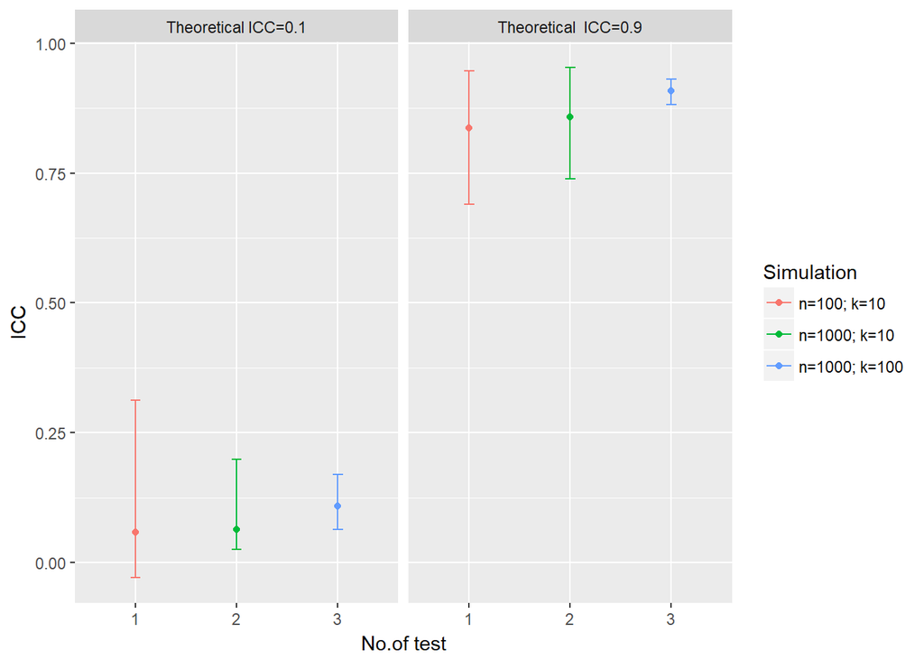

```r
final<-smartbind(Tab1, Tab2, Tab3)
final$simulation<- rep(c("1", "2", "3"), each = 2)
final$Theoretical<-factor(final$Theoretical, labels = c("Theoretical ICC=0.1","Theoretical  ICC=0.9" ))
#using ggplot2 to visualize the result.
ggplot(final, aes(x=simulation, y=ICC, color = simulation)) +
          geom_errorbar(aes(ymin=lowerbound, ymax=upperbound), width=.1) +
          geom_line() +
          geom_point()+
          xlab('No.of test')+
          ylab('ICC')+
          facet_wrap(~Theoretical)+
          scale_color_discrete(name="Simulation",
                               breaks=c("1", "2", "3"),
                               labels=c("n=100; k=10", "n=1000; k=10", "n=1000; k=100"))
```

As an attachment, the simulated data were plotted as dot plots.

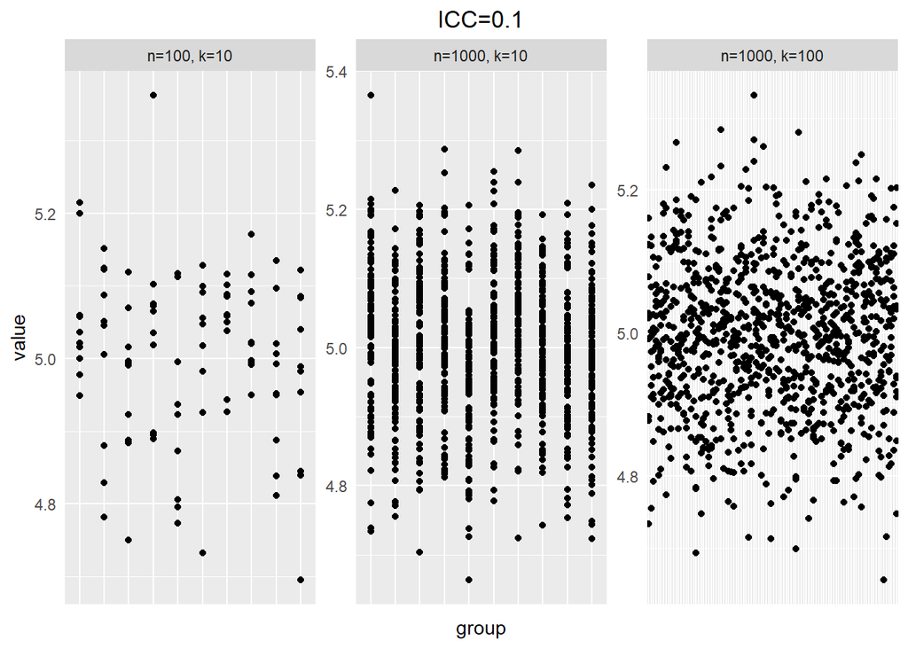

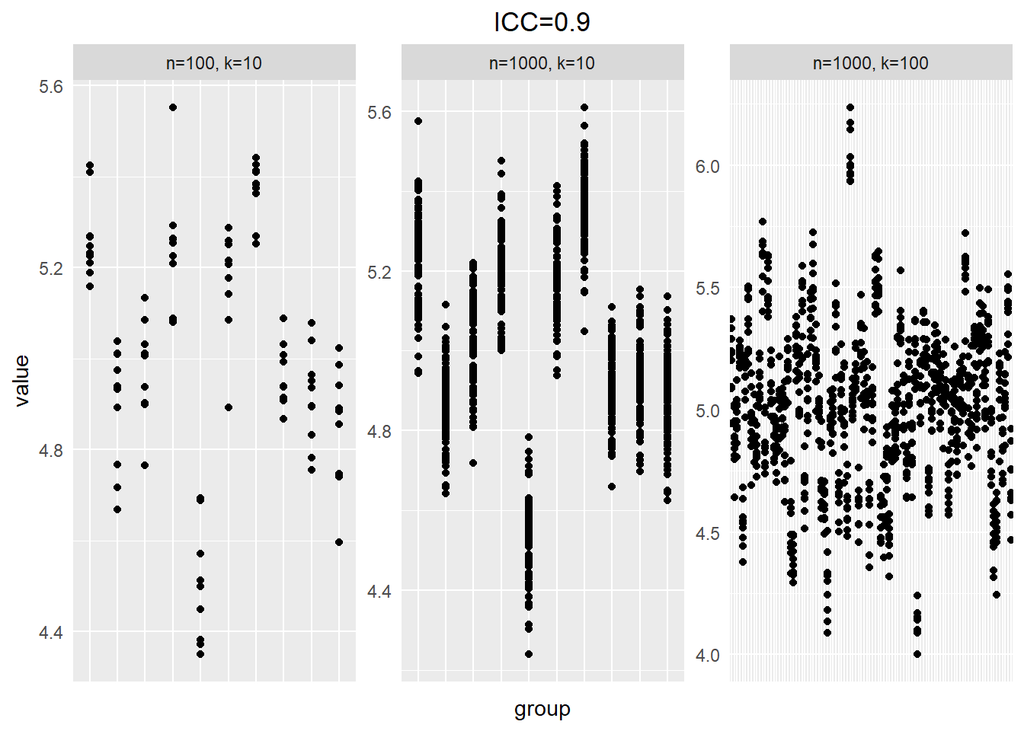

# Working with data

1. Summarizing the data

To summarize the data for one person, I choose data-07 (a). Summarize the data with 3 pre-meal blood glucose measurements (codes 58, 60, 62).

```r
setwd("C:/Users/bitga/Downloads/diabetes-data")
dat<-read.table("data-07", col.names = c("Date", "Time", "Code", "Value"))
sum_tab<-dat %>% filter(Code == 58|Code == 60|Code == 62) %>% group_by(Code) %>%
  summarise(Average = paste0(round(mean(Value, na.rm=TRUE), digits = 2), "(", round(sd(Value),
                             digits = 2), ")"),
            Min = min(Value),
            Max = max(Value),
            Median = median(Value),
            q1 = quantile(Value, probs = 1/4),
            q3 = quantile(Value, probs = 3/4))
names(sum_tab)[2]<-"Mean (SD)"
sum_tab$Code<-factor(sum_tab$Code, labels = c("Pre-breakfast", "Pre-lunch", "Pre-dinner"))
htmlTable(sum_tab, caption = "Table 4. Summary statistics for blood glucose measurement)")
```

| Table 4. Summary statistics for blood glucose measurement) | Table 4. Summary statistics for blood glucose measurement) Code | Table 4. Summary statistics for blood glucose measurement) Mean (SD) | Table 4. Summary statistics for blood glucose measurement) Min | Table 4. Summary statistics for blood glucose measurement) Max | Table 4. Summary statistics for blood glucose measurement) Median | Table 4. Summary statistics for blood glucose measurement) q1 | Table 4. Summary statistics for blood glucose measurement) q3 |
| --- | --- | --- | --- | --- | --- | --- | --- |
| 1 | Pre-breakfast | 182.53(53.75) | 80 | 284 | 193 | 147.5 | 215 |
| 2 | Pre-lunch | 145.21(57.23) | 50 | 300 | 147 | 103 | 175 |
| 3 | Pre-dinner | 182.66(61.59) | 51 | 274 | 197 | 147 | 218 |

(b). Calculate the ICC

```r
#subset data with specific codes
dat0<-dat %>% filter(Code == 58|Code == 60|Code == 62)
dat0$Code<-factor(dat0$Code)
ICCest(dat0$Code, dat0$Value)$ICC
```

```
## [1] 0.09503872
```

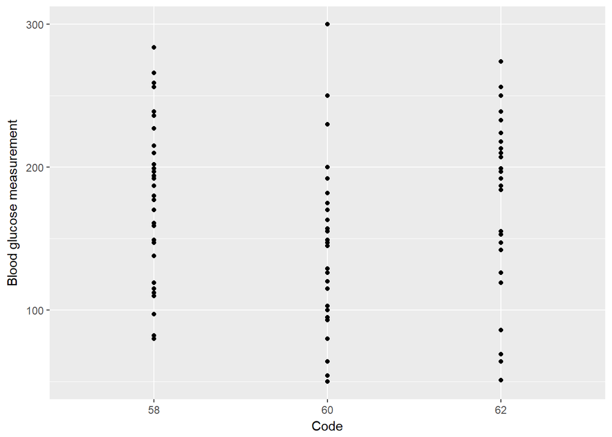

```r
#visualize the data
ggplot(data = dat0, mapping = aes(x = Code, y = Value)) +
       geom_point() +
       xlab("Code")+
       ylab("Blood glucose measurement")
```

Based on the above code, we found the ICC for these three measurements is 0.09503872.

2.(a) Demonstrate the change of blood glucose measurement over time.

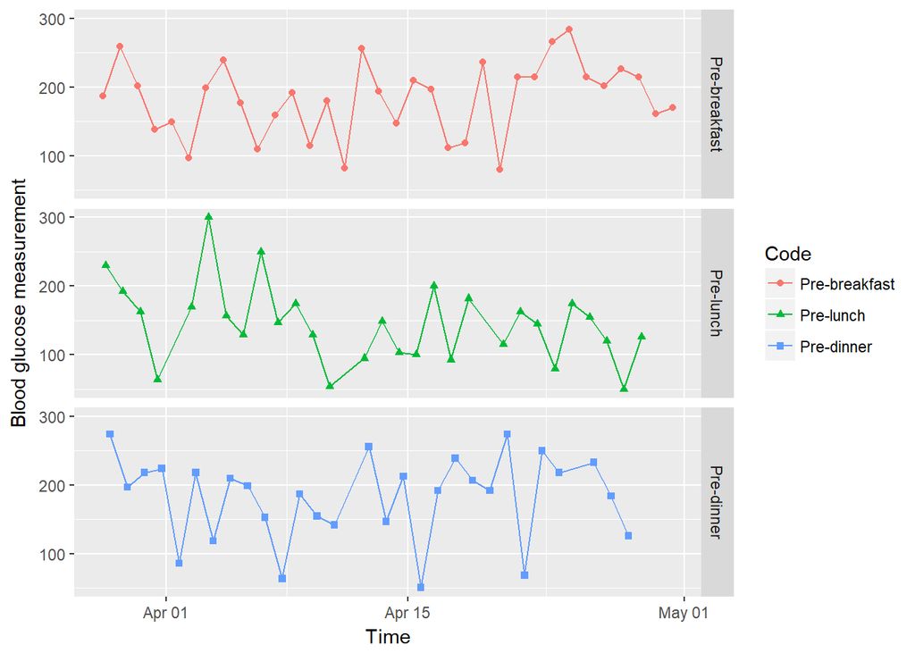

```r
#create an column to illustrate date-time
dat0$Code<-factor(dat0$Code, labels = c("Pre-breakfast",
                                      "Pre-lunch",
                                      "Pre-dinner"))
dat0$Date<-as.character(dat0$Date)
dat0$Time<-as.character(dat0$Time)
dat0$Date_time<-paste(dat0$Date, dat0$Time)
dat0$Date_time<-as.POSIXct(dat0$Date_time, format = "%m-%d-%Y %H:%M")
#using ggplot2 to visualize time-series data
ggplot(data = dat0,
       mapping = aes(x = Date_time, y = Value, shape = Code, colour = Code)) +
       geom_point() +
       geom_line()+
       xlab("Time")+
       ylab("Blood glucose measurement") +
       facet_grid(facets = Code ~ .)
```

(b)Transform the data into wide format on a daily basis

```r
dat1<-dcast(dat0[,c(1,2,3,4)], Code~Date)
head(dat1)
```

```
##            Code 03-28-1989 03-29-1989 03-30-1989 03-31-1989 04-01-1989
## 1 Pre-breakfast        187        259        202        138        149
## 2     Pre-lunch        230        192        163         64         NA
## 3    Pre-dinner        274        197        218        224         86
##   04-02-1989 04-03-1989 04-04-1989 04-05-1989 04-06-1989 04-07-1989
## 1         97        199        239        177        110        159
## 2        170        300        157        129        250        147
## 3        218        119        210        199        153         64
##   04-08-1989 04-09-1989 04-10-1989 04-11-1989 04-12-1989 04-13-1989
## 1        192        115        180         82        256        194
## 2        175        129         54         NA         95        149
## 3        187        155        142         NA        256        147
##   04-14-1989 04-15-1989 04-16-1989 04-17-1989 04-18-1989 04-19-1989
## 1        147        210        197        112        119        236
## 2        103        100        200         93        182         NA
## 3        213         51        192        239        207        192
##   04-20-1989 04-21-1989 04-22-1989 04-23-1989 04-24-1989 04-25-1989
## 1         80        215        215        266        284        215
## 2        115        163        145         80        175        155
## 3        274         69        250        218         NA        233
##   04-26-1989 04-27-1989 04-28-1989 04-29-1989 04-30-1989
## 1        202        227        215        161        170
## 2        120         50        126         NA         NA
## 3        184        126         NA         NA         NA
```

```r
#sum up missing value in the data with wide format
sum(is.na(dat1))
```

```
## [1] 10
```

We found there are 10 missing values in the transformed data

(c). Correlation plot was created as below:

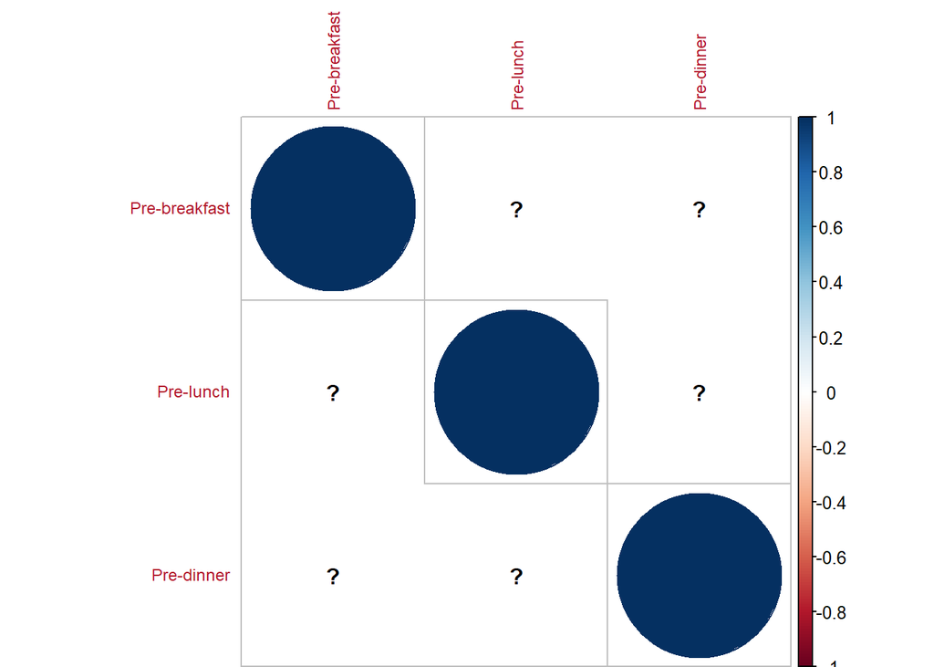

```r
dat2<-t(dat1[,-1])
colnames(dat2)<-c("Pre-breakfast", "Pre-lunch", "Pre-dinner")
M<-cor(dat2)
corrplot(M, tl.cex = 0.75, tl.col = "#B2182B")
```

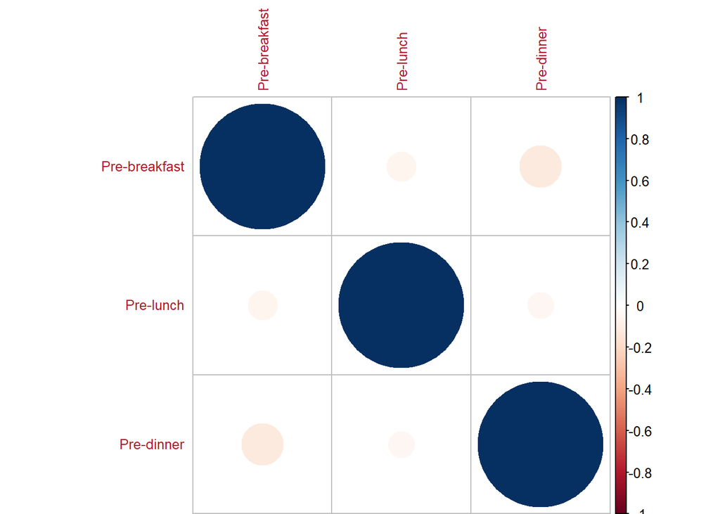

```r
#after removing NA values, the figure turns into:
M1<-cor(dat2, use='complete.obs')
corrplot(M1,tl.cex = 0.8, tl.col = "#B2182B")
```

(d). Data imputation i). Carry the last observation forward separately for each of the 3 categories. Correlation plot was updated as below:

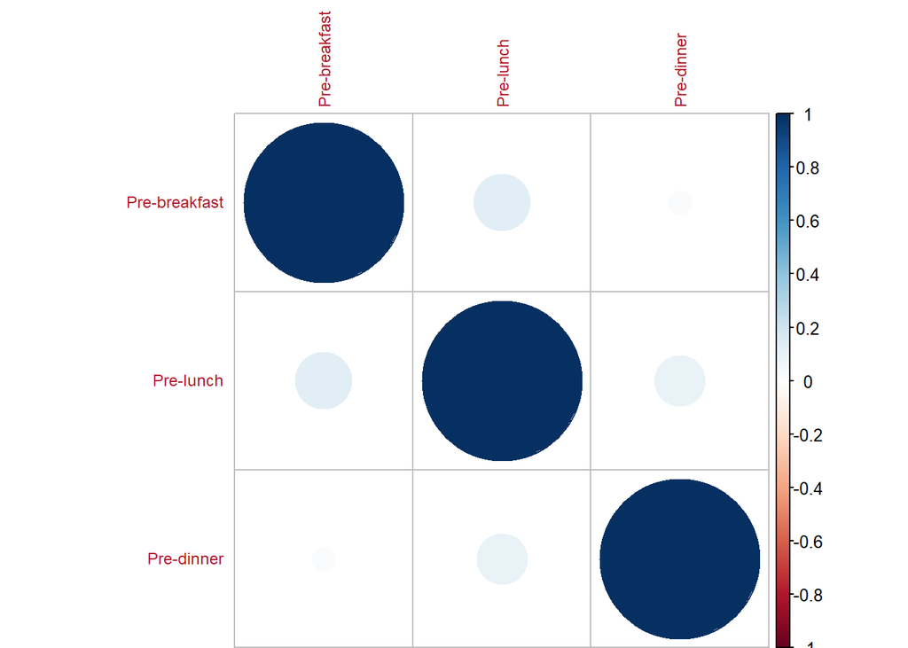

```r
data_locf_days<-na.locf(dat2)
M3<-cor(data_locf_days)
corrplot(M3,tl.cex = 0.75, tl.col = "#B2182B")
```

2. Carry the last observation forward from the time of day (i.e. impute glucose before lunch using glucose before breakfast). The corrplot was updated as below.

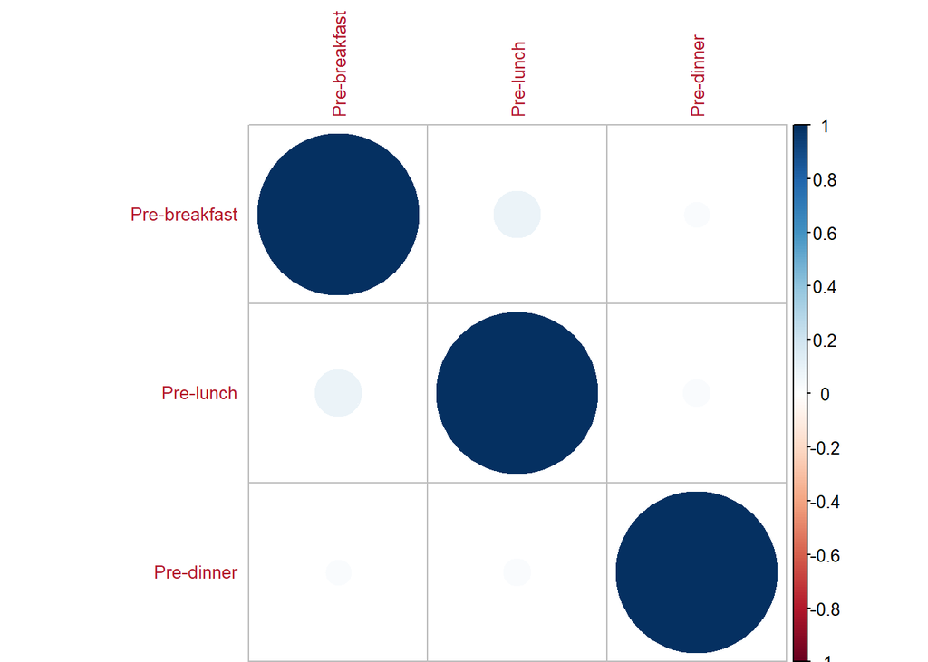

```r
data_locf_time<-t(na.locf(t(dat2)))
M4<-cor(data_locf_time, use = "all.obs")
corrplot(M4, tl.cex = 0.8, tl.col = "#B2182B")
```

# Smoothing

(a)Using lowess function to smooth the time series plot with a binwidth of 0.1

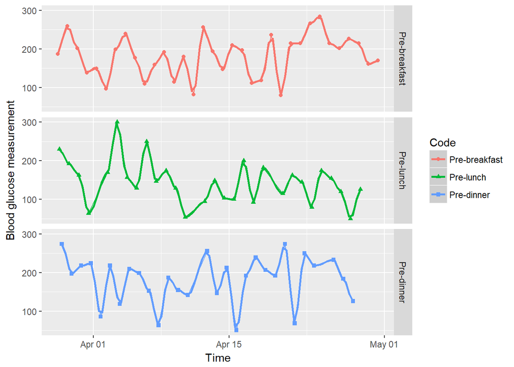

```r
#using ggplot2 to visualize time-series data and lowess function to smooth the curves
ggplot(data = dat0,
       mapping = aes(x = Date_time, y = Value, shape = Code, colour = Code)) +
       stat_smooth(method = "loess", span = 0.1)+
       geom_point() +
       geom_line()+
       xlab("Time")+
       ylab("Blood glucose measurement") +
       facet_grid(facets = Code ~ .)
```

(b)Using lowess function to smooth the time series plot with a binwidth of 0.9

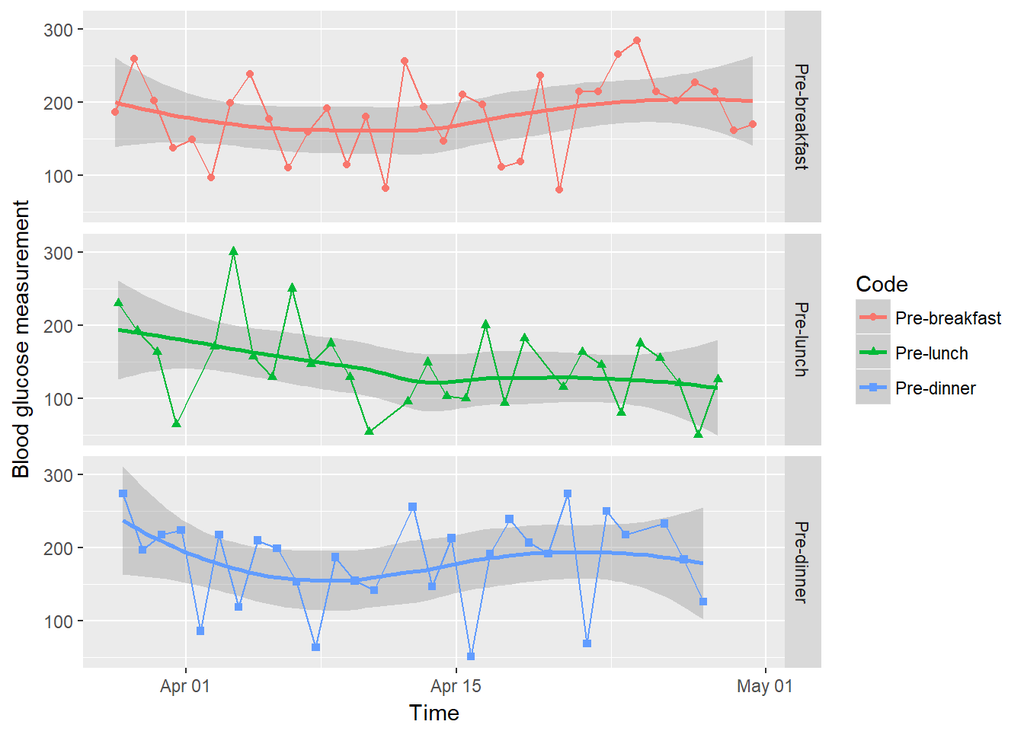

```r
ggplot(data = dat0,
       mapping = aes(x = Date_time, y = Value, shape = Code, colour = Code)) +
       stat_smooth(method = "loess", span = 0.9)+
       geom_point() +
       geom_line()+
       xlab("Time")+
       ylab("Blood glucose measurement") +
       facet_grid(facets = Code ~ .)
```

3. When the binwidth is very small, the curves seems not to be smoothed.
4. As the binwidth (Span) changes, the accuracy of fitted smoothed curves would also be changed. There is a trade-off between fidelity and smoothness. When span is 0.1, there is nearly no smoothing. When span is 0.9, the accuracy of fitted curves is low. Thus I choose a middle value between 0.1 and 0.9, which is 0.5.

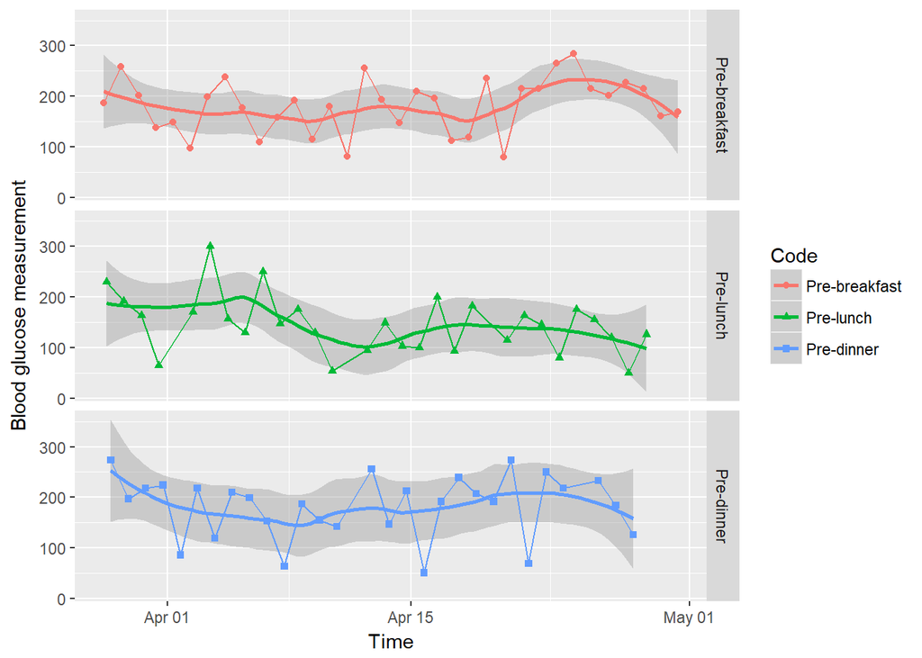

```r
ggplot(data = dat0,
       mapping = aes(x = Date_time, y = Value, shape = Code, colour = Code)) +
       stat_smooth(method = "loess", span = 0.5)+
       geom_point() +
       geom_line()+
       xlab("Time")+
       ylab("Blood glucose measurement") +
       facet_grid(facets = Code ~ .)
```

Here I used moving average to smooth the curves

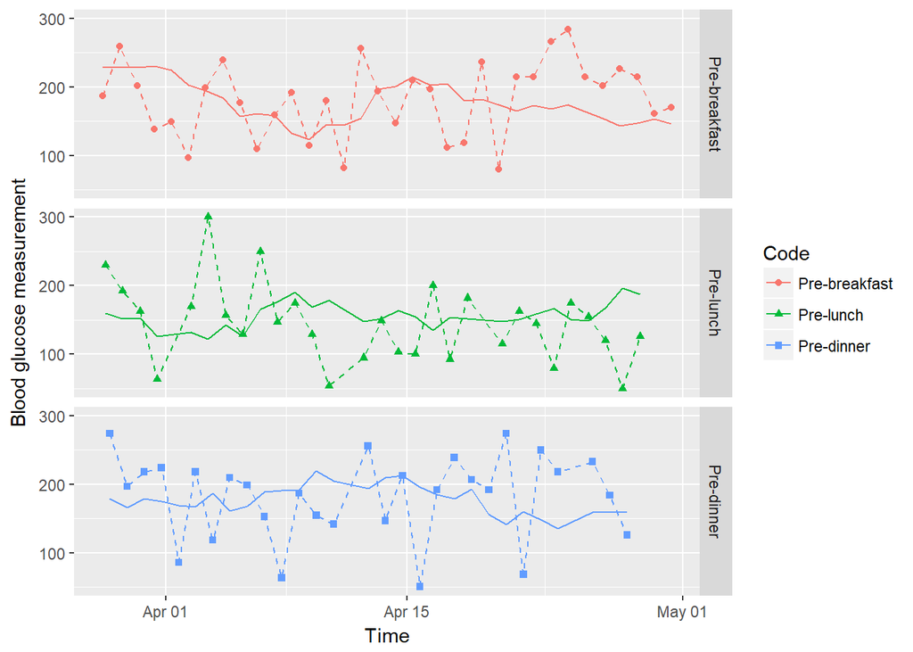

```r
dat.zoo<-zoo(dat0$Value, dat0$Date_time)
#calculate moving average by the windows of 5
moving.mean<-rollmean(dat.zoo, 5, fill = "extend")
#add it to existing data frame
dat0$mv.mean<-coredata(moving.mean)
ggplot(data = dat0,
       mapping = aes(x = Date_time, y = Value, shape = Code, colour = Code)) +
       geom_point() +
       geom_line(linetype = "dashed")+
       geom_line(aes(y = moving.mean))+
       xlab("Time")+
       ylab("Blood glucose measurement") +
       facet_grid(facets = Code ~ .)
```

Based on the plots, I think LOESS smoothing is better than running mean. Curves smoothed by LOESS are visually more elegant and had less roughness than by running mean.

# Comments

I compared my results with Jing Lyu’s. The major results including simulation and data visualization were comparable. Here are some differences: 1). Jing used a function from a package to summarize statistics for blood glucose by different code, which is nice and presented more information than mine. 2). In smoothing questions, Jing used LOESS function differently on different codes (i.e. with different span size). I used ggplot2 and its smoothing feature in which the span size remains constant across different codes. 3). Jing used kernal smoothing in question 2d) while I used moving mean as an alternative to LOESS. Jing thought kernal smoothing is better than LOESS in this scenario.